# Predicting readmission rates for diabetic patients

- Introduction
- Objective

Data exploration

- Describing the dataset
- Patient duplicates?
- Dealing with missing values
- Re-coding values and collapsing features

Data prep

- Removing outliers
- Label encoding

Decision tree

- Feature selection
- Pre-pruning
- Post-pruning
- Takeaways

## Introduction

Diabetes is a long-term health condition that is characterized by high blood sugar levels, as the pancreas is not able to produce enough insulin or when the body is not able to use insulin effectively to regulate blood sugar.

Diabetes is a common comorbidity among hospitalized patients, with studies such as these by [Ostling and colleagues (2017)](https://clindiabetesendo.biomedcentral.com/articles/10.1186/s40842-016-0040-x) and [Soh and colleagues (2020)](https://www.ncbi.nlm.nih.gov/pmc/articles/PMC7418689/) showing that the 30-day readmission rates for hospitalized patients with diabetes are higher than readmission rates for all hospitalized patients.

Therefore, understanding factors that contribute to the high readmission rates of diabetic patients allows healthcare institutions to better care for patients. This doesn't only *most crucially* places the mantra of 'patient-centred care' at the forefront of the medical profession, but from an economic point of view, reduces medical bills and makes for a more efficient use of hospital resources.

## Objective

The objective of this exercise is to answer the below questions:

1) What are the strongest predictors of hospital readmission for patients with diabetes?

2) Can we predict hospital readmission for patients with diabetes?

A decision tree will be used on a [diabetes dataset](https://archive.ics.uci.edu/ml/datasets/Diabetes+130-US+hospitals+for+years+1999-2008) provided by the UCI Machine Learning Repository.

```python
# Import libraries
import pandas as pd
import numpy as np
from tqdm import tqdm
from sklearn import tree
from sklearn.tree import DecisionTreeClassifier
from sklearn.metrics import accuracy_score, confusion_matrix
from sklearn.model_selection import train_test_split
from sklearn.model_selection import RandomizedSearchCV, GridSearchCV
import graphviz
import pydotplus
import matplotlib.pyplot as plt
import matplotlib.image as pltimg
import seaborn as sns

%matplotlib inline
```

## Data exploration

The dataset represents 10 years of clinical data (between 1999 and 2008) across 130 US hospitals and integrated delivery networks. Each row of the dataset represents a patient's inpatient encounter with a hospital for at least 1 day and at most 14 days of length in stay, due to diabetic-related conditions. The dataset includes over 50 features of various patient and hospital outcomes, including race, gender, age, admission type, hospital time, test results, and readmission status (no readmission, readmitted in less than 30 days, readmitted after 30 days).

Below is the first 5 rows of the dataset.

|  | encounter_id | patient_nbr | race | gender | age | weight | admission_type_id | discharge_disposition_id | admission_source_id | time_in_hospital | ... | citoglipton | insulin | glyburide-metformin | glipizide-metformin | glimepiride-pioglitazone | metformin-rosiglitazone | metformin-pioglitazone | change | diabetesMed | readmitted |
| --- | --- | --- | --- | --- | --- | --- | --- | --- | --- | --- | --- | --- | --- | --- | --- | --- | --- | --- | --- | --- | --- |
| 0 | 2278392 | 8222157 | Caucasian | Female | [0-10) | ? | 6 | 25 | 1 | 1 | ... | No | No | No | No | No | No | No | No | No | NO |
| 1 | 149190 | 55629189 | Caucasian | Female | [10-20) | ? | 1 | 1 | 7 | 3 | ... | No | Up | No | No | No | No | No | Ch | Yes | >30 |
| 2 | 64410 | 86047875 | AfricanAmerican | Female | [20-30) | ? | 1 | 1 | 7 | 2 | ... | No | No | No | No | No | No | No | No | Yes | NO |
| 3 | 500364 | 82442376 | Caucasian | Male | [30-40) | ? | 1 | 1 | 7 | 2 | ... | No | Up | No | No | No | No | No | Ch | Yes | NO |
| 4 | 16680 | 42519267 | Caucasian | Male | [40-50) | ? | 1 | 1 | 7 | 1 | ... | No | Steady | No | No | No | No | No | Ch | Yes | NO |

5 rows × 50 columns

We see that **54%** of patients of the dataset were not readmitted, **35%** were readmitted after 30 days, and only **11%** were readmitted before 30 days.

Since classification problems are sensitive to class imbalance, I will combine the before and after 30 days of readmission into a single group of readmission.

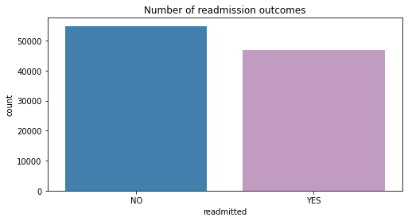

**Patient duplicates**

`patient_nbr` indicates the unique identifier for each patient. We see that there are duplicates in the patient IDs.

It may be that the 'unique' identifier is the same for different patients who attend different hospitals. If so, then the IDs are simply not in synced across different hospitals.

When I look at the duplicated `patient_nbr` IDs, I noticed that data recorded across the other features are different, which either implies the above, or that each patient ID represents a unique ADMISSION across time, regardless of whether or not the patient has had more than one admission within the same hospital.

In any case, I will not be removing these patient ID duplicates.

**Missing values**

Missing values of the dataset are represented as `?`. Features with missing values are `race`, `weight`, `payer_code`, `medical_specialty`, `diag_1`, `diag_2`, and `diag_3`.

- `race`: 2% of patients did not disclose their races. I will drop these patients from the dataset.
- `weight`: 97% of weights are not filled. This represents a very large portion of the dataset. I will remove this feature entirely from my dataset.
- `payer_code`: 40% of payer codes were not filled. In this instance, it is difficult to impute missing payer codes, given that there are currently 23 distinct payer codes. I will also remove this feature entirely from my dataset.
- `medical_specialty`: 49% of medical specialties, which indicate the specialty of the admitting physician, are missing. I will also remove this feature entirely from my dataset.

I also drop the identifiers of patients as they do not provide me with any insight: `encounter_id` and `patient_nbr`.

**Re-code values and collapsing features**

Now, I re-group values of features where necessary, whether based on similar characteristics or similar trends with regards to readmission outcome. This is to reduce the multidimensionality of the dataset.

However, since I do not have a strong knowledge in the medical domain, I try to employ as much common sense as available to me in cases where patterns of differentiation may be observed.

**1) Gender**

The plots show a similar pattern of readmission outcome between female and male patients - there are more patients who were not readmitted across both genders. However, we see that a higher proportion of female patients were readmitted, as compared to male patients.

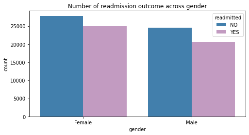

**2) Age**

The ages of patients were recorded in categorical ranges in intervals of 10: 0-10, 10-20, 20-30 etc.

All age groups seem to share a similar pattern of readmission outcome, with a higher number of no readmissions than readmissions. We see however, that the proportion of readmissions is higher among older groups (we see a narrower gap in the height of bars between blue and purple above 70 years of age, as compared to ages between 40 and 70).

In addition, I will convert this feature from a categorical to numeric, by taking the mid-point of each age group.

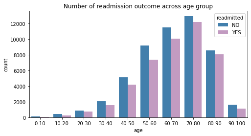

**3) Admission type**

There are 9 distinct admission types that are represented in unique integers. Admission types are: `emergency`, `urgent`, `elective`, `newborn`, `trauma`. There are also undisclosed admission types that are recorded as `other`.

Since they are recorded in integers, I will map them to their admission types in string format so that I can look at them better. The integers and their corresponding admission types can be found [here](https://archive.ics.uci.edu/ml/machine-learning-databases/00296/).

In the plot below, we see that all trauma patients of the dataset did not get readmitted. Seems like the largest proportion of patients who were readmitted come from admission types `other` and `emergency`. On the other hand, `newborn` and `elective` had the lowest proportion of readmissions.

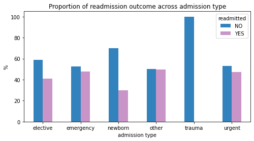

I will remove patients with undisclosed admission types, and re-group all non-emergency admission types into one group called `non-emergency`.

In the plot below, we see that among patients who were admitted due to emergency reasons, a higher proportion were readmitted, as compared to those who came in due to non-emergency reasons.

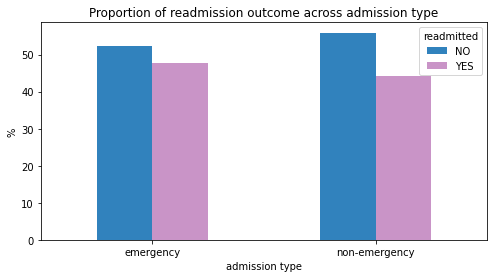

**4) Discharge disposition**

There are 29 distinct discharge reasons. For example, a patient may be discharged home or discharged to another medical institution, which takes various forms such as short term hospital, inpatient care institution, Medicare approved swing bed, and many more. I will group all discharge destinations that are not to a patient's home (even if it is a home with home health services) as being discharged to a medical institution.

Another thing to note is that some discharge reasons were recorded as `expired`. These are patients that had passed away during their admission, which I remove from the dataset. I also remove patients with undisclosed discharge dispositions.

The plot below shows that the largest proportion of patients who were readmitted are those who left against medical advice, while the smallest proportion are those who were discharged home.

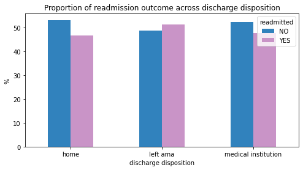

**5) Admission source**

There are 21 distinct admission sources describing the source of which patients were referred for the initial admission, such as physical referral, clinic referral, emergency referral, and others.

Looks like most patients were admitted from the emergency room, followed by physician referrals. Other sources include transfer from another healthcare facility, from another critical access hospital, from an ambulatory surgery centre, and others.

I will drop this feature from my dataset, seeing as I am unsure of how the various referral sources differ or overlap in service with each other. Furthermore, I'd imagine that these admission sources are also reflective of the admission types (emergency, elective, newborn etc), which we have in the dataset.

**6) Duration of hospital stay in days**

Unlike the categorical features that I was describing before, this feature is numerical, indicating the number of days a patient was admitted in the hospital. The shortest hospital stay is 1 day while the longest is 14 days.

Our dataset shows that a majority of patients were admitted for less than 6 days, with a decreasing number as days increase to 14 days (reflecting a rightly-skewed histogram).

For my decision tree, I will not be log-transforming this feature into a normally distributed plot, since this feature is not the target variable.

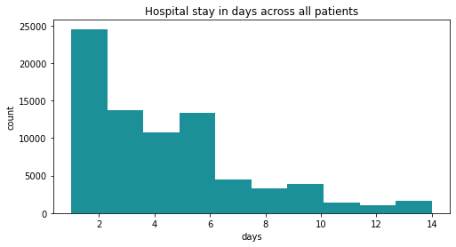

Let us look at the relationship between readmission outcome and the amount of time spent during admission.

From the boxplots below, we see that patients who did not get readmitted had a lower *median* number of admission days (**3 days**), as compared to patients who did get readmitted (**4 days**). Nevertheless, we see a significant overlap in the number of admission days for both readmission outcomes.

The *average* number of days for patients who were readmitted is also *slightly* higher than those who were not (**4.5 days** vs **4.2 days**).

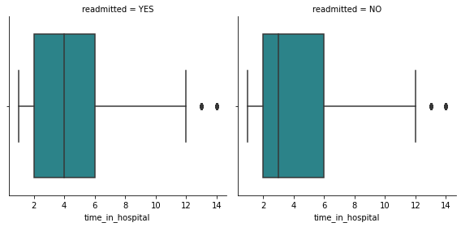

We see that a larger proportion of patients who were not readmitted had a shorter admission time, as compared to patients who were readmitted.

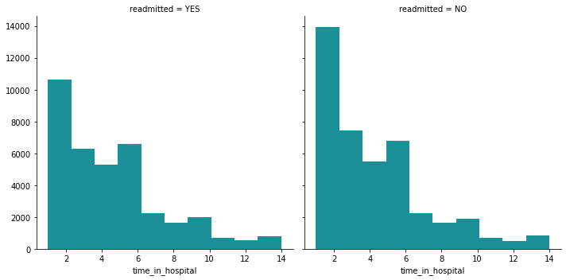

**7) Number of lab tests performed**

The lowest number of lab tests performed on patients of the dataset is 1, while the highest is 132 tests.

The histograms below show a similar distribution of number of lab procedures performed across both readmission groups. Nevertheless, the average number of lab tests given to patients who were admitted is slightly higher (44 tests) than for patients who were not readmitted (42 tests).

The boxplots show overlapping number of lab procedures across both readmission groups.

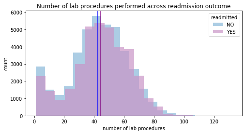

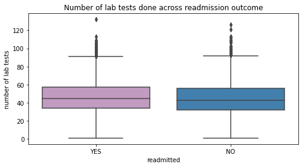

**8) Number of non-lab procedures performed**

The lowest number of non-laboratory tests performed on patients of the dataset is 0, while the highest is 6.

The pattern of non-lab tests performed across readmission outcomes is similar to the number of lab tests performed. So, I combine both these features into a single feature called `num_tests`.

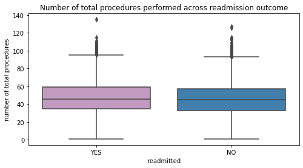

**9) Number of medications**

The lowest number of medications given to patients of the dataset is 1, while the highest is 81.

The average number of medications given among patients who were readmitted is higher (16.3) than for patients who were not readmitted (15.4).

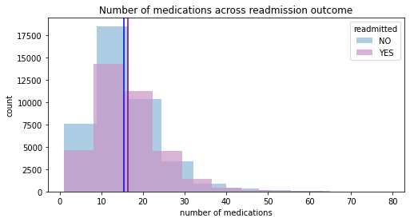

**10) Number of outpatient visits in the preceding year**

The lowest number of outpatient visits is 0 and the highest is 42.

A great majority of patients from both readmission outcomes had 0 outpatient visits. However, there is a higher number of larger outliers among patients who were readmitted.

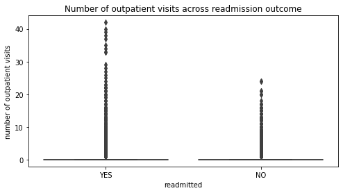

**11) Number of emergency visits in the preceding year**

Similar to the number of outpatient visits, a vast majority of patients (**88%**) had 0 emergency visits in the year before their admission, followed by **7.5%** who only had 1 emergency visit. Also, there is a higher number of larger outliers in the number of emergency visits among patients who were readmitted vs patients who were not.

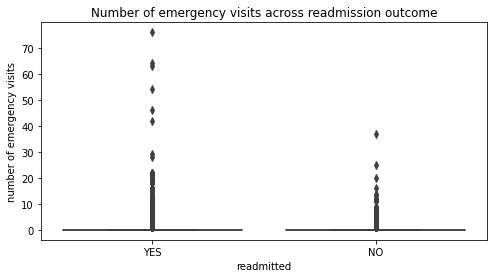

**12) Number of inpatient visits in the preceding year**

A larger proportion of patients who were readmitted had at least 1 inpatient visit, as compared to a majority of patients who were not readmitted, who majorly had 0 inpatient visits.

This is in contrast to the number of *outpatient* and *emergency* visits, where 0 outpatient and 0 emergency visits seem to be the norm amongst patients.

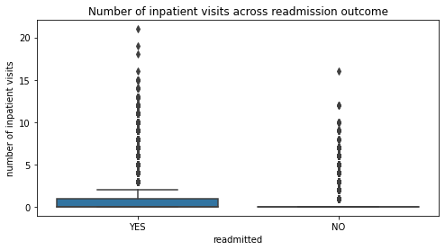

I combine the number of inpatient, outpatient, and emergency visits into a single feature: `num_services_utilized`.

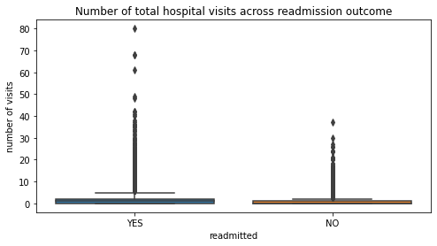

**13) ICD-9 diagnoses**

The dataset has 848 distinct diagnoses that are recorded across patients as their primary diagnosis, along with 923 distinct secondary diagnoses, and 954 distinct additional secondary diagnosis.

I will not be looking at the secondary and additional secondary diagnoses, only the primary ones.

```python
# define classification function
def classify_diagnosis_codes(df):
    if 1 <= df <= 139:
        return 'infectious and parasitic diseases'
    elif 140 <= df <= 239:
        return 'neoplasms'
    elif 240 <= df <= 279:
        return 'endocrine, nutritional, metabolic diseases, immunity disorders'
    elif 280 <= df <= 289:
        return 'diseases of the blood'
    elif 290 <= df <= 319:
        return 'mental disorders'
    elif 320 <= df <= 389:
        return 'diseases of the nervous system'
    elif 390 <= df <= 459:
        return 'diseases of the circulatory system'
    elif 460 <= df <= 519:
        return 'diseases of the respiratory system'
    elif 520 <= df <= 579:
        return 'diseases of the digestive system'
    elif 580 <= df <= 629:
        return 'diseases of the genitourinary system'
    elif 630 <= df <= 679:
        return 'complications of pregnancy, childbirth'
    elif 680 <= df <= 709:
        return 'diseases of the skin'
    elif 710 <= df <= 739:
        return 'diseases of the musculoskeletal system'
    elif 740 <= df <= 759:
        return 'congenital anomalies'
    elif 760 <= df <= 779:
        return 'originating in the perinatal period'
    elif 780 <= df <= 799:
        return 'symptoms, signs, and ill-defined conditions'
    elif 800 <= df <= 999:
        return 'injury and poisoning'
    elif 1000 <= df < 2000:
        return 'factors affecting health status'
    elif df >= 2000:
        return 'external causes of injury'
    else:
        return df
```

The top three conditions that were the primary diagnoses of patients are (1) diseases of the circulatory system; (2) endocrine, nutritional, metabolic diseases, and immunity disorders; and (3) diseases of the respiratory system.

I will re-group all diseases related to infants and pregnancies to a single group `maternal and child`.

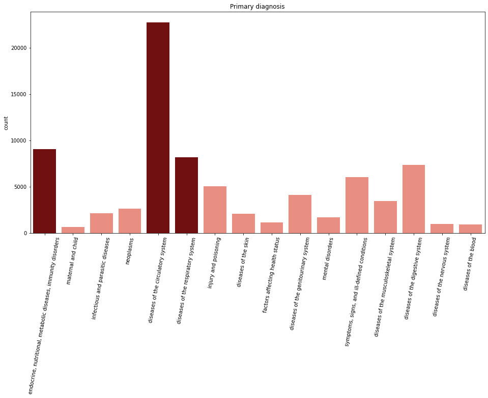

When we look at the proportion of readmission outcome across all primary diagnoses, we see in particular that a larger proportion of diabetic patients with (1) diseases of the blood; (2) diseases of the respiratory system; and (3) diseases of the endocrine, nutritional, metabolic and immunity system, were readmitted than not.

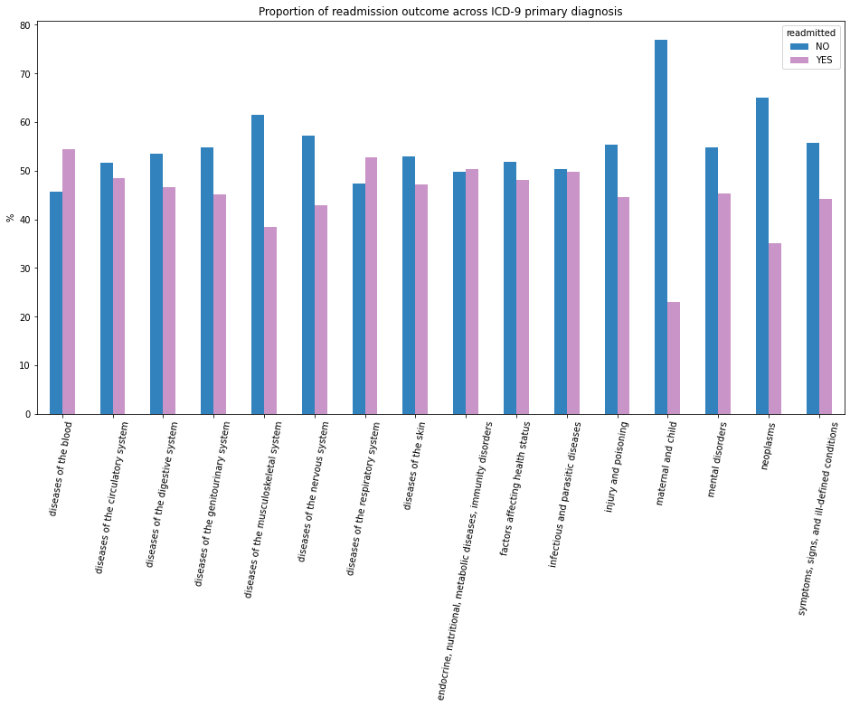

**14) Number of diagnoses**

The number of diagnoses that was entered into the system. 16 is the highest number of diagnoses while 1 is the least. Most patients had 9 conditions diagnosed, at **48%**.

The median number of diagnoses is higher among patients who were readmitted as compared to those who were not. Nevertheless, there are still major overlaps between the box plots.

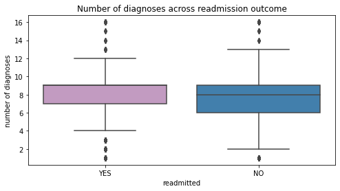

**15) Glucose serum test results**

The glucose serum test is a blood glucose test that screens for diabetes by measuring the level of sugar in a person's blood.

The dataset records the blood sugar measurements in categories (`>200`, `>300`, `normal`), or if the test was not taken (`none`). **94%** of patients did not have their glucose serum tests taken.

The bar charts show us that among patients who had taken the test, those who recorded >300 had a higher proportion of being readmitted, as compared to patients in the other glucose groups.

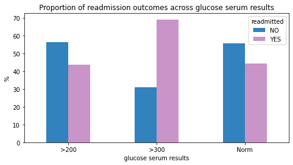

**16) A1c test results**

The A1c test is a blood test that measures a person's average blood sugar levels over the past 3 months.

The dataset records the test results in categories of `>8` if the result is greater than 8%, `>7` if the result is greater than 7% but less than 8%, `normal` if the result is less than 7%, and `none` if the test was not taken by the patient. **83%** of patients did not have their A1c test taken.

As compared to the glucose serum test results, A1c test results do not seem to have an obvious pattern with readmission outcome.

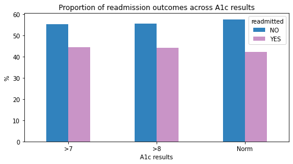

**17) Changes in medication dosage - per medicine**

The dataset includes 24 different medications that were either taken by patients in an increasing dosage, decreasing dosage, a steady dosage, or it was not taken at all. The medications include metformin, repaglinide, nateglinide, chlorpropamide, and many others.

Since all patients did not take examide and citoglipton (as indicated in all the values recorded under these 2 features as `no`), I will remove these 2 features from my dataset.

**18) Change of medications**

This feature indicates if there had been a change in **diabetic medication**, either in terms of dosage, or the medication itself.

Looks like a larger proportion of patients whose medications were changed got readmitted as compared to those whose medications were not changed.

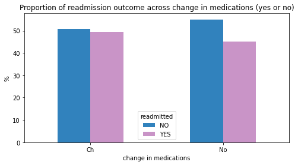

```python
# create a table of proportions
output6 = pd.crosstab(df['change'], df['readmitted']).apply(lambda x: round((x/x.sum())*100, 1), axis=1)

output6.plot.bar(figsize=(8,4), color=['#3182bd','#c994c7'])
plt.title('Proportion of readmission outcome across change in medications (yes or no)')
plt.xticks(rotation=360)
plt.xlabel('change in medications')
plt.ylabel('%');
```

**19) Diabetes medications**

Describes whether or not any diabetic medications were prescribed: `yes` or `no`.

The table below shows us the stats.

| diabetesMed | change | change |
| --- | --- | --- |
| No | No | 17396 |
| Yes | Ch | 36678 |
|  | No | 24078 |

## Removing outliers from numeric features

I define the outlier threshold as lower than and higher than a z-score of -3 and +3 respectively.

```python
# get all numeric features with outliers
to_remove_outliers = []

for i in df.columns:
    if (df[i].dtype == 'int64') or (df[i].dtype == 'float64'):
        to_remove_outliers.append(i)
    else:
        pass

print(f"These features have outliers: {', '.join(to_remove_outliers)}")
```

```
These features have outliers: age, time_in_hospital, num_medications, number_diagnoses, num_tests, num_services_utilized
```

```python
from scipy import stats

# identify outliers and remove them from features
for i in to_remove_outliers:
    df['z_score'] = stats.zscore(df[i])
    df = df.loc[(df['z_score'] >= -3) & (df['z_score'] <= 3)]
```

## Label encode categorical features

Now that I have explored my features/ predictor variables, dealt with missing data, re-grouped values, and removed outliers, I will be converting my categorical values into numeric values before feeding the decision tree model with the dataset. This is because Python Scikit Learn's decision tree algorithms work best with numeric inputs.

At this point...I am in a bit of a dilemma, because since my categorical features are nominal (aka they do not have a natural ordering to the categories), it is conventional to apply one-hot encoding to them. However, my dataset contains categorical features with high number of categories (high [cardinality](https://www.quora.com/Do-we-need-to-convert-categorical-data-to-numerical-data-before-applying-to-decision-tree)), such as feature: `primary diagnosis` (it has more than 10 distinct categories). One-hot encoding this feature would result in [sparse data](https://www.quora.com/Do-we-need-to-apply-one-hot-encoding-to-use-xgboost), which is not great. So, I decided to [label encode](https://towardsdatascience.com/categorical-encoding-using-label-encoding-and-one-hot-encoder-911ef77fb5bd) all categorical features.

```python
# identify categorical features
to_encode = []

for i in df.columns:
    if df[i].dtype == 'O':
        to_encode.append(i)

# label encode features
for i in to_encode:
    df[i] = df[i].astype('category')
    df[i + '_cat'] = df[i].cat.codes
```

## Feature selection

Now that I have my features cleaned and encoded, I identify features that are [most important](https://towardsdatascience.com/feature-selection-techniques-in-machine-learning-with-python-f24e7da3f36e) in the decision tree when predicting our target variable, `readmitted`. Removing less important features would help us achieve a better prediction accuracy for our decision tree model, reduces overfitting, and reduces training time.

I calculate the feature importances of each feature of my dataset using a preliminary model where I include all features.

```python
# select features/ predictor variables
features = []

for i in df.columns:
    if df[i].dtype == 'int8':
        features.append(i)
    elif df[i].dtype == 'int64':
        features.append(i)
    else:
        pass

# remove the target variable
features.remove('readmitted_cat')

# seperate features and target variable
X = df[features]
y = df['readmitted']
```

## Preliminary decision tree

Decision trees are like flow charts, with each level constituting nodes that contain unique conditions that split or differentiate target outcomes according to certain features. The goal of these splits is to be able to ultimately produce as clean or as pure of a separation between the target outcomes, according to the information gain of nodes.

```python
# split dataset to training and test data using default 70:30 ratio
X_train, X_test, y_train, y_test = train_test_split(X, y, stratify=y, random_state=0)

# run decision tree
dtree_prelim = tree.DecisionTreeClassifier(random_state=0) # instantiate classifier
clf_prelim = dtree_prelim.fit(X_train, y_train)
y_train_pred_prelim = clf_prelim.predict(X_train)
y_test_pred_prelim = clf_prelim.predict(X_test)
```

**Accuracy score**

We see that the preliminary model overfits the data massively - the accuracy score for the test data is **54%**, while the accuracy score for the training data is **99%**.

```
Train score: 0.9999640223061702
Test score: 0.5475689385354271
```

**Confuson matrix**

A confusion matrix is used to summarise the performance of a classification model according to its prediction results.

```python
# define function to plot confusion matrix
def plot_confusion_matrix(y_train_pred, y_train, dom):
    print(f"{dom} Confusion Matrix")
    cf = confusion_matrix(y_train_pred, y_train)
    sns.heatmap(cf,
                annot=True,
                yticklabels=['Readmitted','Not readmitted'],
                xticklabels=['Readmitted','Not readmitted'],
                cmap='Blues',
                fmt='g')
    plt.tight_layout()
    plt.xlabel('Predicted')
    plt.ylabel('Actual')
    plt.show()
```

```
Test Confusion Matrix
```

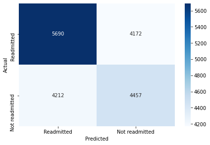

**Feature importance**

Looking at the feature importance scores below, I will retain the top 10 features with the highest scores, while dropping the remaining features from dataset/ decision tree.

The top 10 features in descending order are:

- Number of total tests (lab and non-lab)
- Number of medications
- Time in hospital
- Primary diagnosis
- Age
- Number of total inpatient, outpatient, and emergency visits
- Number of diagnoses
- Change in insulin dosage
- Gender
- Race

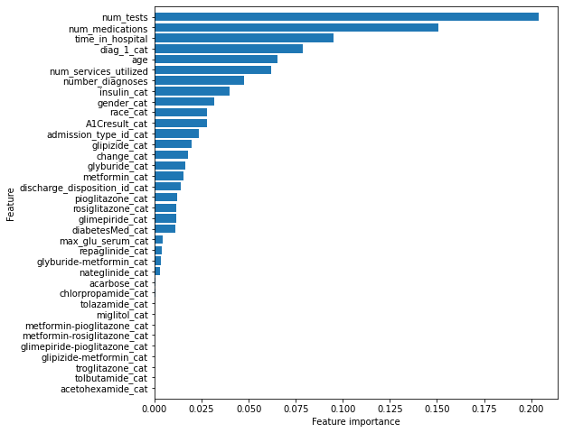

```python
# define function to plot horizontal bar charts
def plot_feature_importances(model):
    plt.figure(figsize=(8,8))
    n_features = len(features)
    plt.barh(range(n_features), feature_importance, align='center')
    plt.yticks(np.arange(n_features), feature_names)
    plt.xlabel("Feature importance")
    plt.ylabel("Feature")
    plt.ylim(-1, n_features)

# visualise feature importance scores
plot_feature_importances(clf_prelim)
```

## Pre-pruning

Decision trees are great, but they easily overfit, which explains the high prediction accuracy score for the training set, but a much lower score for the test set. To solve this, we can limit or stop the growth of the decision tree by changing the classifier's parameters such as the criterion, depth of the tree, a minimum sample before a leaf is allowed to exist, and more. This technique of changing these parameters is called [pre-pruning](https://www.kaggle.com/arunmohan003/pruning-decision-trees-tutorial).

Because there are so many potential combinations from the different mix of values of the parameters, we use a [grid search](https://www.dezyre.com/recipes/optimize-hyper-parameters-of-decisiontree-model-using-grid-search-in-python) to carry out the parameter cross-validation for us. Grid search chooses the optimum value for each parameter for us - values that in combination, give the best performance for the decision tree model.

I will be using **criterion**, **splitter**, **max_depth**, **min_samples_split**, and **min_samples_leaf**.

```python
# set parameters
params = {'criterion': ['gini'],
          'splitter': ['best', 'random'],
          'max_depth': np.arange(2,20),
          'min_samples_split': np.arange(2,10),
          'min_samples_leaf': np.arange(2,10)}

# use grid search to find optimum values
dtree_preprune = tree.DecisionTreeClassifier()
gcv = GridSearchCV(estimator=dtree_preprune, param_grid=params)
gcv.fit(X_train, y_train)

# use optimal values to re-train pre-pruned tree
clf_preprune = gcv.best_estimator_
clf_preprune.fit(X_train, y_train)
y_train_pred_preprune = clf_preprune.predict(X_train)
y_test_pred_preprune = clf_preprune.predict(X_test)
```

```
Best criterion: gini
Best splitter: best
Best max_depth: 4
Best min_samples_split: 2
Best min_samples_leaf: 2
```

```
Train score: 0.6191221442705522
Test score: 0.614915546921375
```

From the 2nd set of pre-pruned accuracy scores, we see a tradeoff between accuracy and generalizability - the accuracy score for the test data increased from **54%** to **61%**, at a cost of having the accuracy score for the training data decrease from **99%** to **62%**. The difference between the training and test accuracy scores is now lower.

Below is how the tree looks like.

```python
dot_data = tree.export_graphviz(clf_preprune, out_file=None,
                                feature_names=X_train.columns.tolist(),
                                class_names=['readmitted','not readmitted'],
                                filled=True, rounded=True,
                                special_characters=True)

graph = graphviz.Source(dot_data)
graph
```

[figure not shown]

## Post-pruning

Setting constraints to the parameters such as the pre-pruning technique above is one way to avoid overfitting. However, another way to avoid overfitting is by using [cost complexity pruning, or also known as the weaklest link pruning](https://scikit-learn.org/stable/auto_examples/tree/plot_cost_complexity_pruning.html). The gist of this technique is that it is used to control the size of the tree by finding the right parameter for alpha (which is the cost complexity parameter). Alpha is then used to calculate the [tree score](https://www.youtube.com/watch?v=D0efHEJsfHo) for each pruned tree by taking into account the sum of squared residuals (SSR) and the number of leaves of each tree (which corresponds to each alpha):

> **tree score = SSR + (alpha * total number of leaves)**

Different alphas and their corresponding trees (with different SSRs and number of leaves) give various tree scores, in which case the tree with the lowest tree score is chosen.

**Implement cost complexity pruning**

`cost_complexity_pruning_path` returns a sequence of effective alphas that is later used to determine what the most appropriate alpha (ccp_alpha) is.

In the plot below, we see that the higher the alpha, the higher the impurity of leaves, implying a more pruned tree (a tree with a lower number of nodes).

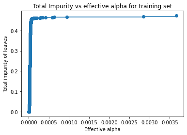

```python
# calculate alphas
clf = tree.DecisionTreeClassifier()
path = clf.cost_complexity_pruning_path(X_train, y_train)
ccp_alphas, impurities = path.ccp_alphas, path.impurities

# plot relationship between alphas and impurity of leaves
fig, ax = plt.subplots()
ax.plot(ccp_alphas[:-1], impurities[:-1], marker='o', drawstyle="steps-post")
ax.set_xlabel("Effective alpha")
ax.set_ylabel("Total impurity of leaves")
ax.set_title("Total Impurity vs effective alpha for training set");
```

Next, we create multiple pruned trees using all effective alphas produced before, so that we can eventually pick an alpha that [maximises testing accuracy](https://medium.com/swlh/post-pruning-decision-trees-using-python-b5d4bcda8e23) without compromising much of the training accuracy.

```python
# train models for each alpha
clfs = []

for i in tqdm(ccp_alphas):
    clf_postprune_alpha = tree.DecisionTreeClassifier(ccp_alpha=i)
    clf_postprune_alpha.fit(X_train, y_train)
    clfs.append(clf_postprune_alpha)
```

We plot how the different alphas influence the number of nodes and depths of the corresponding pruned trees.

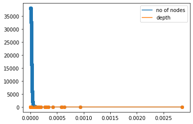

```python
# remove last alpha
clfs = clfs[:-1]
ccp_alphas = ccp_alphas[:-1]

# store node counts and depths
node_counts = []
depth = []

# get node counts and depths of each model/ alpha
for clf in tqdm(clfs):
    node_counts.append(clf.tree_.node_count)
    depth.append(clf.tree_.max_depth)

plt.scatter(ccp_alphas, node_counts)
plt.scatter(ccp_alphas, depth)
plt.plot(ccp_alphas, node_counts, label='no of nodes', drawstyle="steps-post")
plt.plot(ccp_alphas, depth, label='depth', drawstyle="steps-post")
plt.legend()
```

Let's visualise the training and testing accuracy scores for each pruned tree along with the tree's alpha.

Seems like the best alpha to use that gets us the maximal accuracy score for the test set is `0.00015`, although the accuracy score of the training set is also severely compromised, from the preliminary model.

That said, this alpha gives us accuracy scores (**62%** and **62%**) that are still very similar to the pre-pruned tree (**62%** and **61%**).

In addition, the post-pruned tree has a depth of 5, as opposed to the pre-pruned tree of having a depth of 4.

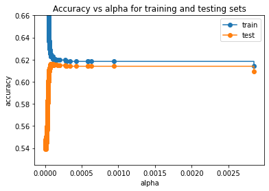

```python
# store scores for plotting
train_scores = []
test_scores = []

# for each clf (corresponding to each alpha), get the accuracy score for the training and test data
for clf in tqdm(clfs):
    train_scores.append(clf.score(X_train, y_train))
    test_scores.append(clf.score(X_test, y_test))

# plot
fig, ax = plt.subplots()
ax.set_xlabel('alpha')
ax.set_ylim(0.525, 0.66)
ax.set_ylabel('accuracy')
ax.set_title('Accuracy vs alpha for training and testing sets')
ax.plot(ccp_alphas, train_scores, marker='o', label='train', drawstyle='steps-post')
ax.plot(ccp_alphas, test_scores, marker='o', label='test', drawstyle='steps-post')
ax.legend()
```

```python
# select optimum alpha for the post-pruned tree
dtree_postprune_final = tree.DecisionTreeClassifier(ccp_alpha=0.00015)
clf_postprune_final = dtree_postprune_final.fit(X_train, y_train)
y_train_pred_postprune3 = clf_postprune_final.predict(X_train)
y_test_pred_postprune3 = clf_postprune_final.predict(X_test)
```

```
Train score: 0.6200755531570427
Test score: 0.6156710377205763
```

[figure not shown]

## Takeaways

This exercise leveraged demographic and clinical data of diabetes patients in the US to build a predictive model to identify patients who are likely to be redmitted to the hospital (versus patients who are likely to not be readmitted).

I only implemented a decision tree classifier as my predictive model, which yielded an accuracy of **62%** with the post-pruned tree as having the highest accuracy score as compared to the preliminary model and pre-pruned tree.

The key factors that were used by the model for prediction are number of total tests done, number of medications, time spent in hospital during previous admission, type of primary diagnosis, and the age of a patient. Some other factors that were important include the number of visits a patient paid to the hospital (whether for inpatient, outpatient, or emergency purposes), number of diagnoses, and change in insulin dosage.

A few things that I have taken note of, and would hopefully like to study more for an explanation, are (1) the similar accuracy scores between trees using the pre-pruning and post-pruning techniques; (2) how different ways of encoding the categorical features would affect accuracy scores.